# Conformal Prediction — Sulam

## Quantile regression (CQR)

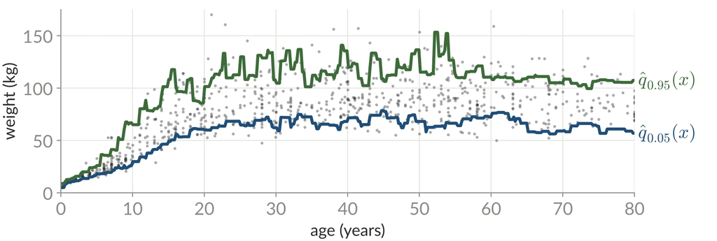

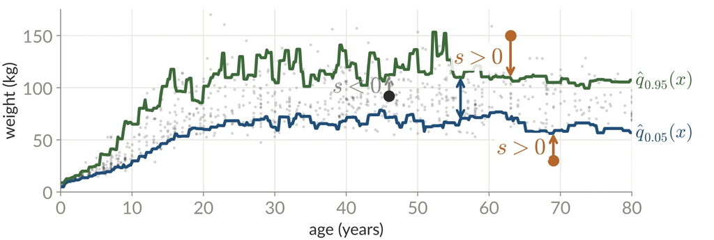

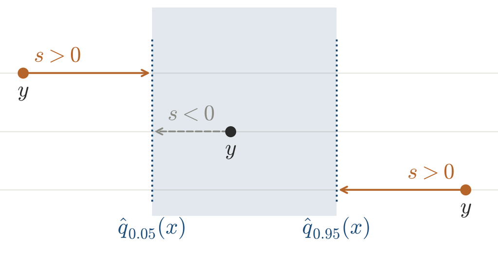

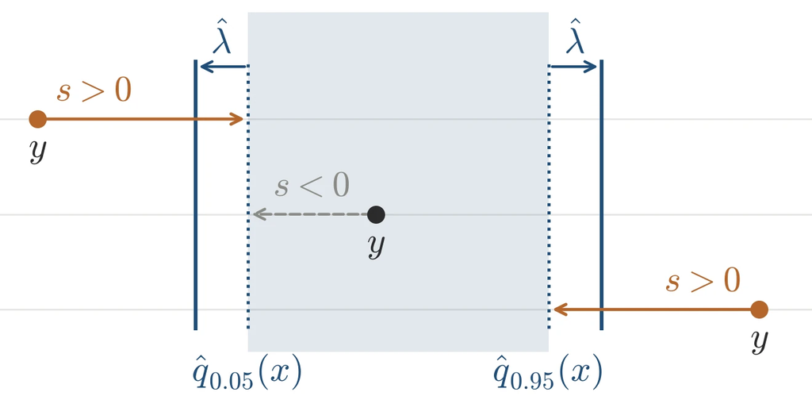

Score: signed distance to the interval
$$s(x,y) = \max\big\{\hat q_{0.05}(x) - y,\ y-\hat q_{0.95}(x)\big\}$$

$$\Ch(x)=\big[\hat q_{0.05}(x)-\qh,\ \hat q_{0.95}(x)+\qh\big]$$

[Romano, Patterson & Candès, 2019]

## Quantile regression

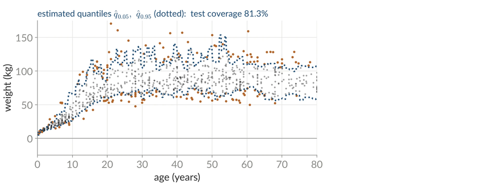

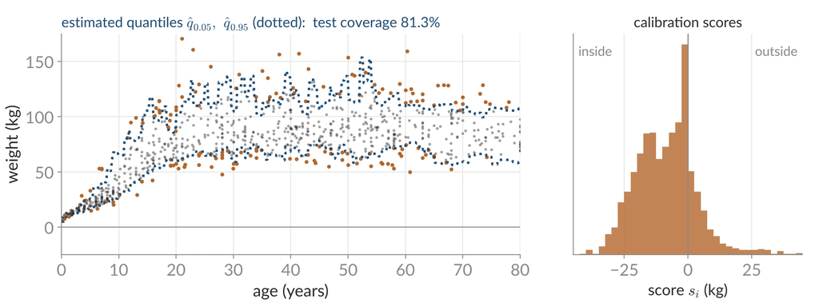

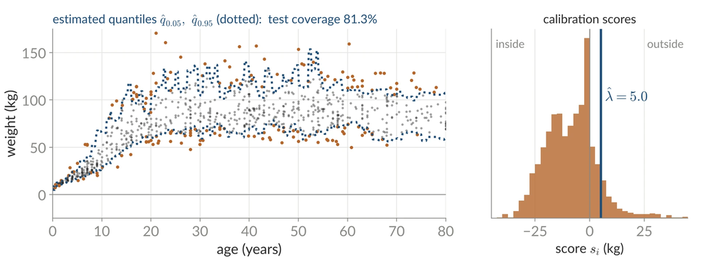

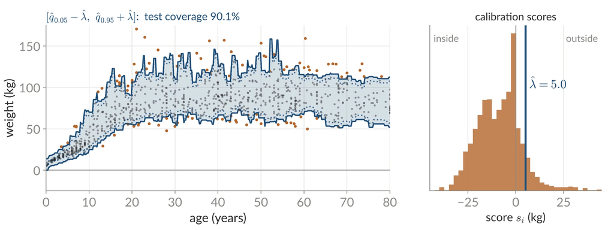

Estimated quantiles: 81.3%. Conformalized ($\qh=5.0$ kg): 90.1%.

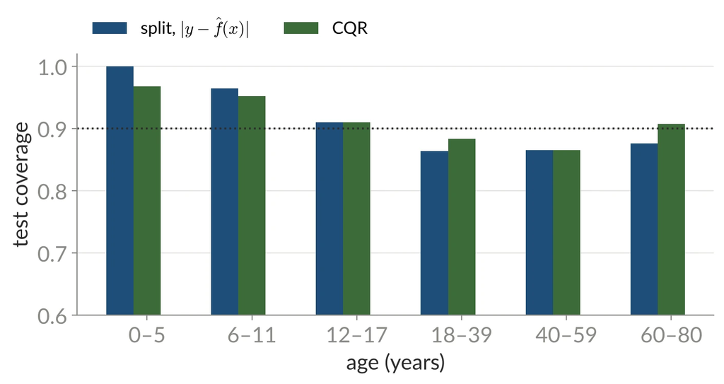

Q2: How does it generalize, and where is it used?

CQR

classification

conditional coverage

risk control

online

## Conformal classification

Now $Y\in\{1,\dots,K\}$ is a **label** (ImageNet: $K=1000$ classes).

The model outputs probabilities $\fh_1(x),\dots,\fh_K(x)$ (softmax) and the usual prediction is $\ \arg\max_y \fh_y(x)$.

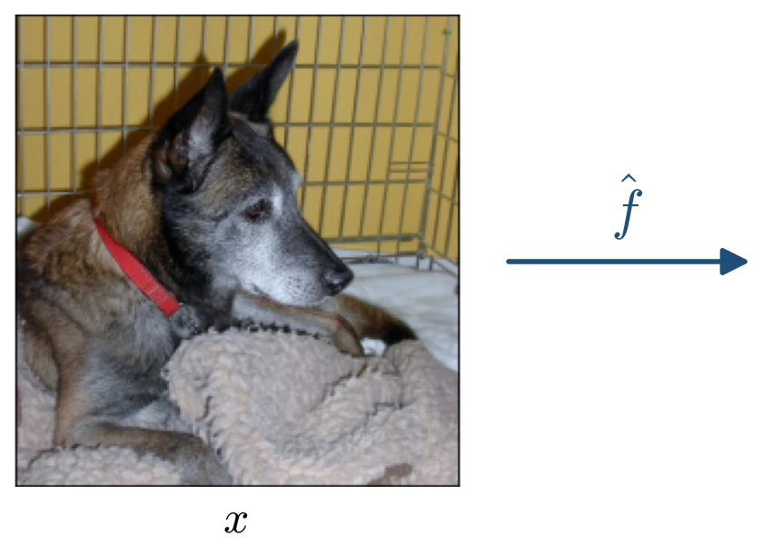

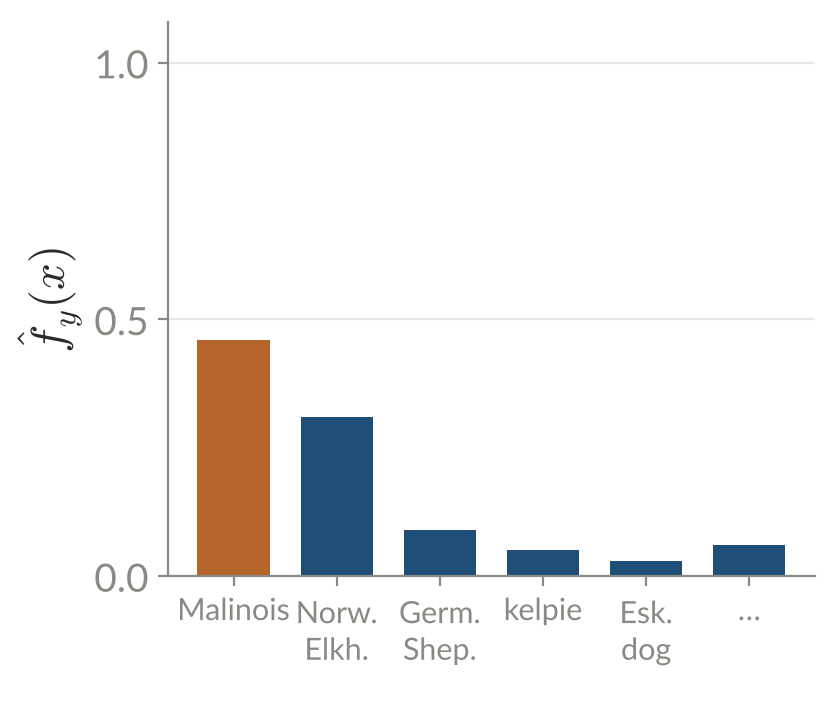

Conformal gives a **set** of labels $\ \Ch(x)\subseteq\{1,\dots,K\}\$ with
$$\P\big(Y\in\Ch(X)\big)\ \ge\ 1-\alpha$$

## Conformal classification

1. Calibration scores

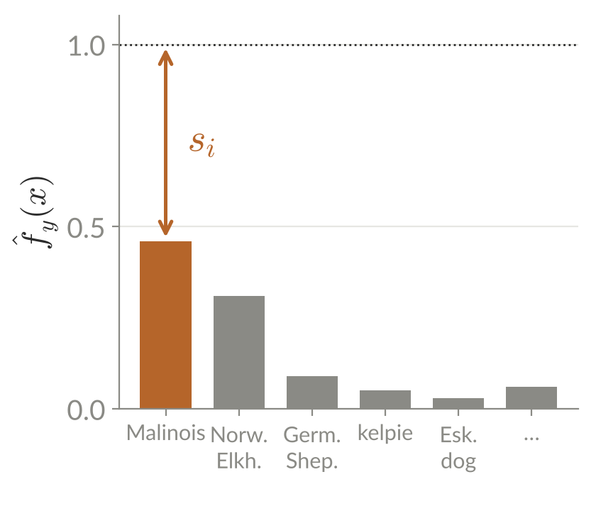

$s_i=1-\fh_{Y_i}(X_i)$

→

2. Quantile of the scores

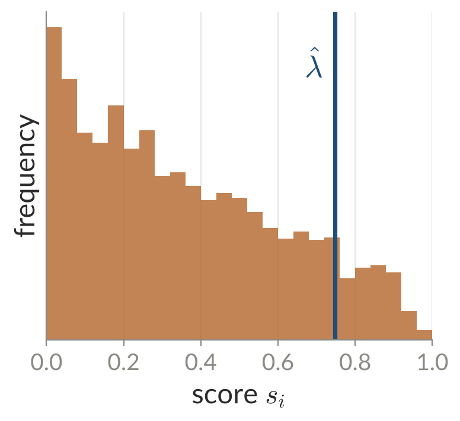

$\qh$ = quantile of level $\tfrac{\lceil (n+1)(1-\alpha)\rceil}{n}$

→

3. Test sets

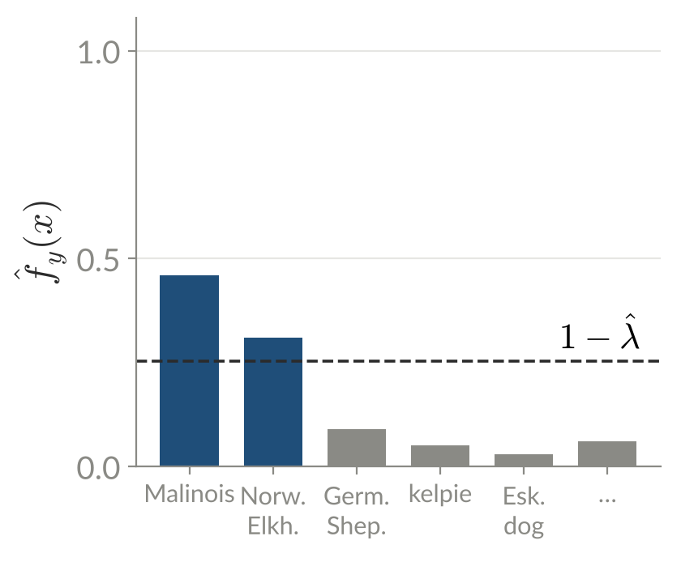

$\Ch(x)=\big\{y:\ \fh_y(x)\ge 1-\qh\big\}$

The only thing that changes is the score.

Theorem. [Vovk et al, 2005; Lei et al, 2018] If $(X_1,Y_1),\dots,(X_{n+1},Y_{n+1})$ are exchangeable, then $\ \P\big(Y_{n+1}\in\Ch(X_{n+1})\big)\ge 1-\alpha$.

## Conformal classification

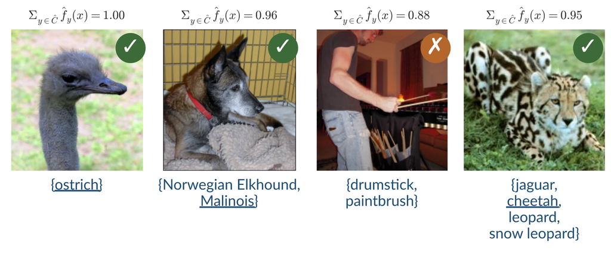

Theorem. [Vovk et al, 2005; Lei et al, 2018] If $(X_1,Y_1),\dots,(X_{n+1},Y_{n+1})$ are exchangeable, then $\ \P\big(Y_{n+1}\in\Ch(X_{n+1})\big)\ge 1-\alpha$.

[Sadinle, Lei & Wasserman, 2019][Angelopoulos & Bates, 2023]

Q2: How does it generalize, and where is it used?

CQR

classification

conditional coverage

risk control

online

## Conditional coverage

Conformal guarantees **marginal** coverage, not **conditional** coverage:

$$\P\big(Y\in\Ch(X)\big)\ge 1-\alpha \qquad\not\Rightarrow\qquad \P\big(Y\in\Ch(X)\mid X=x\big)\ge 1-\alpha$$

Without further assumptions, coverage conditional on $X$ is “impossible”.

It is possible by groups.

[Vovk, 2012][Lei & Wasserman, 2014][Foygel Barber et al, 2021]

## Conditional coverage

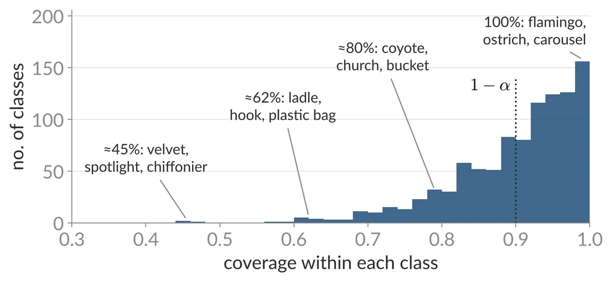

90% on average, but 12% of the classes fall below 80%.

## Conditional coverage

1. Scores per class

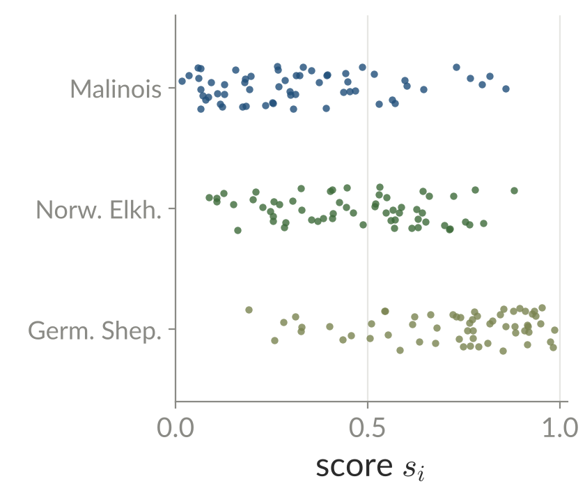

$\{s_i:\ Y_i=y\}$ for each class $y$

→

2. One quantile per class

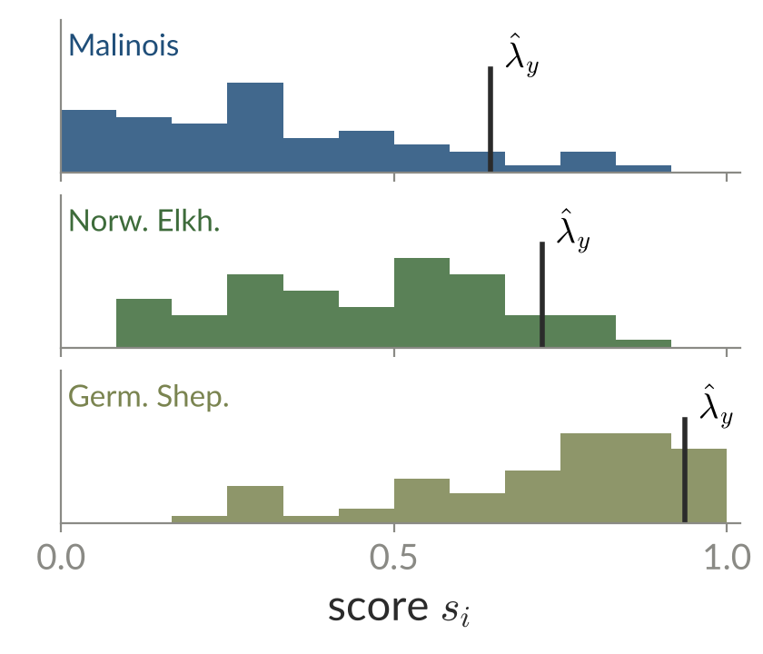

$\qh_y$ = quantile of level $\tfrac{\lceil (n_y+1)(1-\alpha)\rceil}{n_y}$

→

3. Test sets

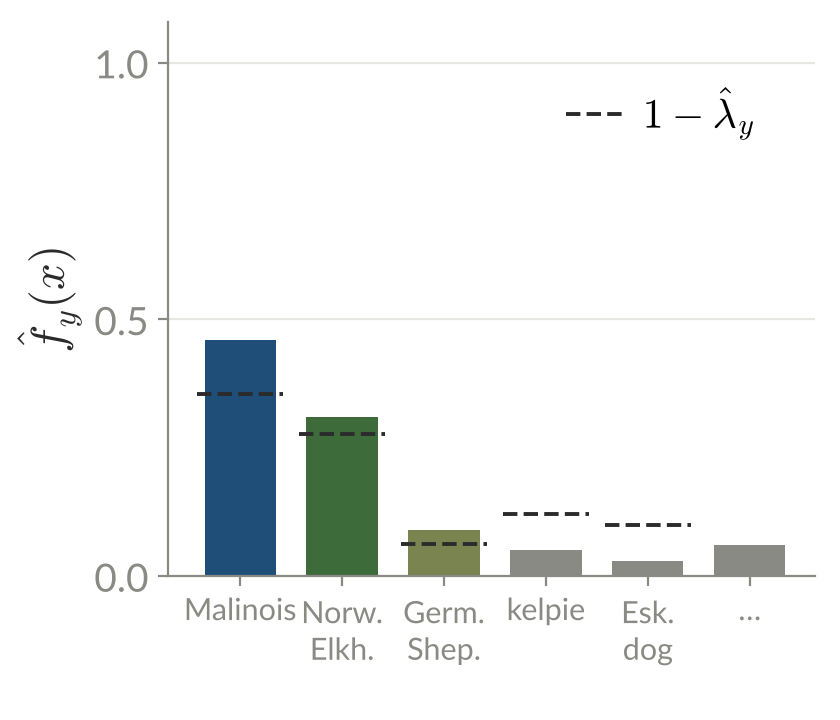

$\Ch(x)=\big\{y:\ \fh_y(x)\ge 1-\qh_y\big\}$

Theorem. [Vovk et al, 2005; Vovk, 2012] If the data are exchangeable, for each class $y$, $\ \P\big(Y_{n+1}\in\Ch(X_{n+1})\mid Y_{n+1}=y\big)\ge 1-\alpha$.

## Conditional coverage

1. Scores per class

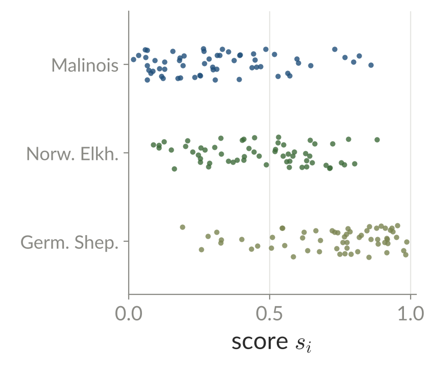

$\{s_i:\ Y_i=y\}$ for each class $y$

→

2. One quantile per class

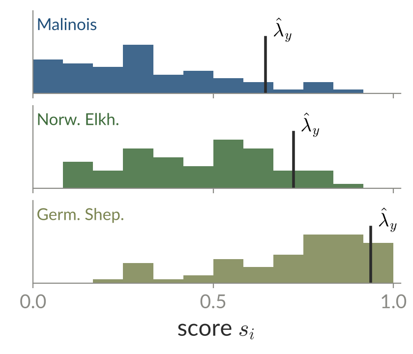

$\qh_y$ = quantile of level $\tfrac{\lceil (n_y+1)(1-\alpha)\rceil}{n_y}$

→

3. Test sets

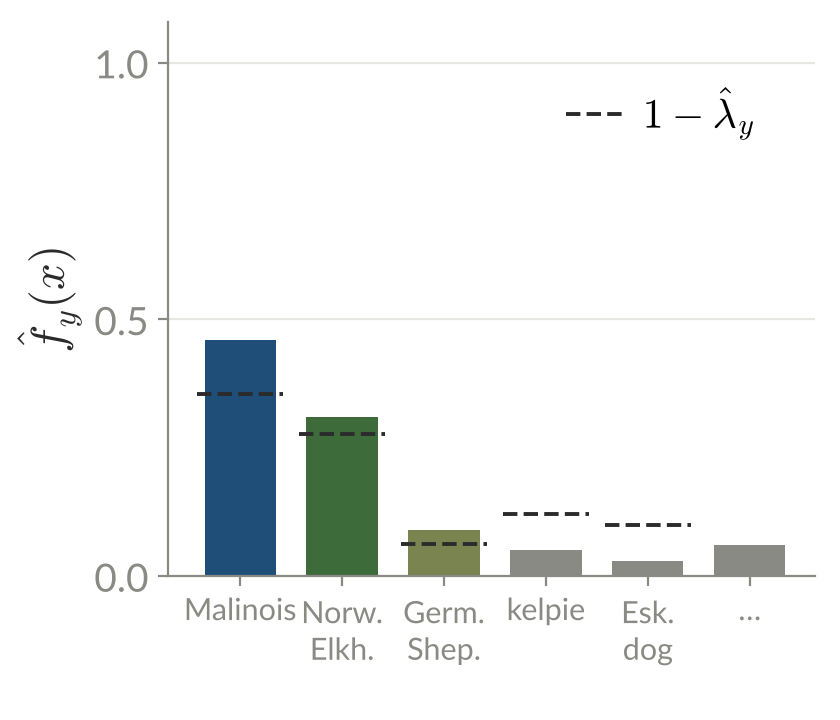

$\Ch(x)=\big\{y:\ \fh_y(x)\ge 1-\qh_y\big\}$

More generally, with **disjoint** groups $g(X,Y)\in\{1,\dots,G\}$ fixed in advance, and one $\qh_g$ per group (exchangeable data), then:

$$\P\big(Y_{n+1}\in\Ch(X_{n+1})\ \big|\ g(X_{n+1},Y_{n+1})=g\big)\ \ge\ 1-\alpha \quad\text{for each } g$$

Examples: the class ($g=y$), age groups, demographic groups, hospital, scanner type.

[Vovk et al, 2005][Vovk, 2012]

## Conditional coverage

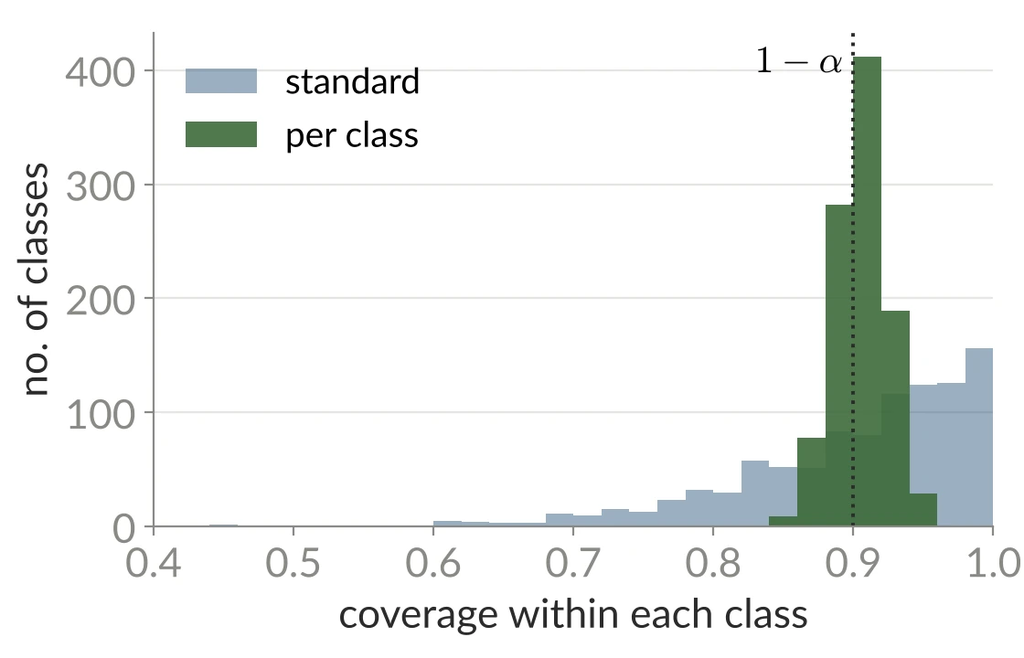

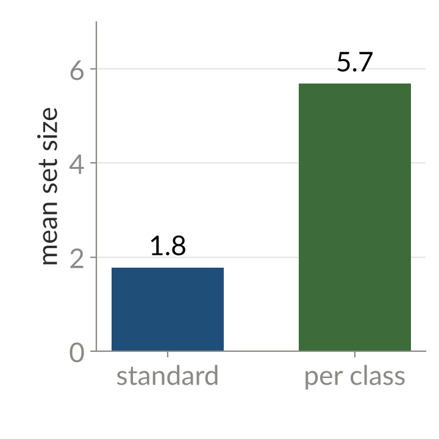

Price: larger sets.

[Ding, Angelopoulos, Bates, Jordan & Tibshirani, 2023]

Q2: How does it generalize, and where is it used?

CQR

classification

conditional coverage

risk control

online

## Conformal regression on images

Measurements

Reconstruction

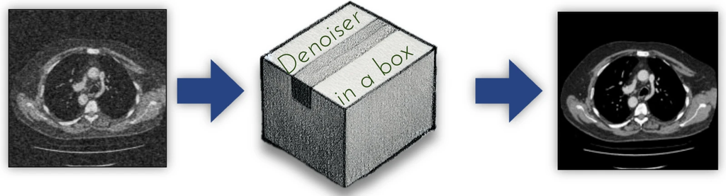

$X=AY+\epsilon,\ \ \epsilon\sim\mathcal N(0,\sigma^2\mathbb I)$

$\hat Y=f_\theta(X)\in\mathbb R^d$

What does it mean to “cover” an image with $d$ pixels?

$$\P\big(Y\notin C_{\qh}(X)\big)=\E\big[\mathbf 1\{Y\notin C_{\qh}(X)\}\big]\le\alpha$$

## From coverage to risk

Split conformal controls the expected value of an indicator:

$$\P\big(Y\notin C_{\qh}(X)\big)=\E\big[\mathbf 1\{Y\notin C_{\qh}(X)\}\big]\le\alpha$$

Replace it with a **loss** $\ L\big(C_\lambda(X),Y\big)\in[0,B]$, **non-increasing** in $\lambda$:

- fraction of pixels outside the band $\big[\hat l(X)-\lambda,\ \hat u(X)+\lambda\big]$
- fraction of missing labels (multi-label, segmentation)
- coverage itself: $\ L=\mathbf 1\{Y\notin C_\lambda(X)\}$

## From coverage to risk

$Y$ (ground truth)

$X$ (measurement)

$\hat l(X)-\qh$

$\hat u(X)+\qh$

width

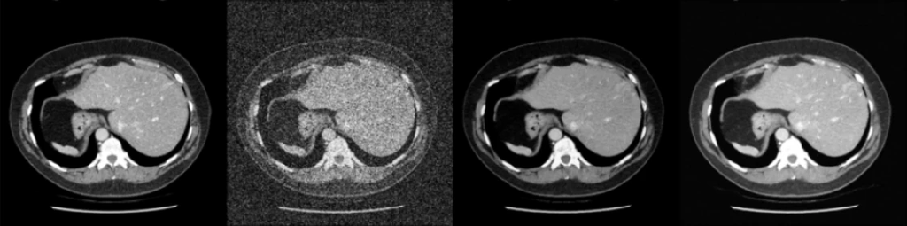

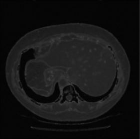

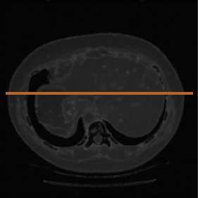

One data point $=$ one image.

[Teneggi, Stayman & S., MICCAI 2025]

## From coverage to risk

$L\big(C_\lambda(X),Y\big)$: fraction of **pixels of $Y$** outside $\big[\hat l_j-\lambda,\ \hat u_j+\lambda\big]$

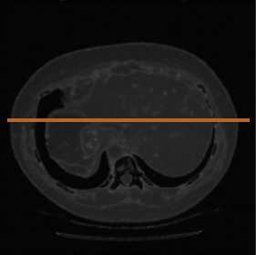

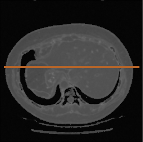

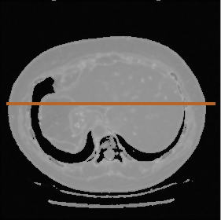

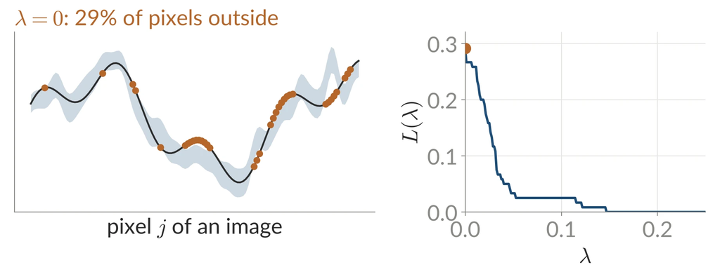

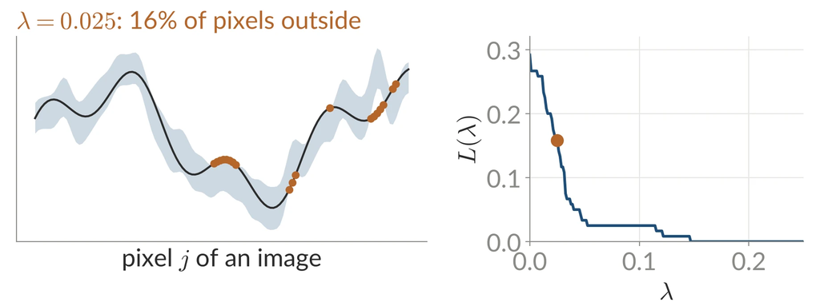

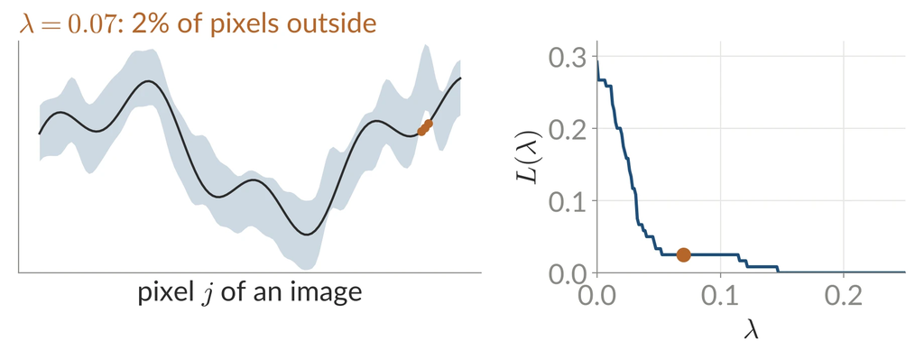

How do we choose $\lambda$ so that $\quad \E\big[L\big(C_{\qh}(X),Y\big)\big]\le\epsilon\$?

## From coverage to risk

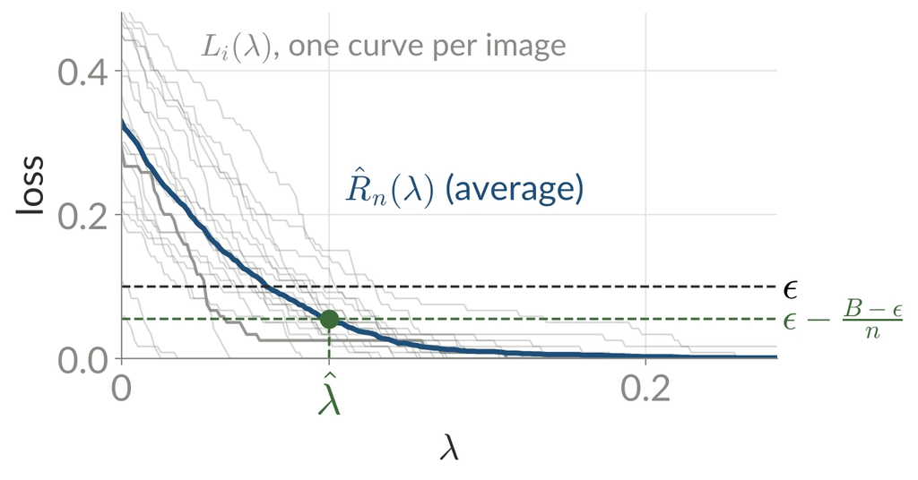

$$\hat\lambda = \inf\Big\{\lambda:\ \hat R_n(\lambda)\le \epsilon-\tfrac{B-\epsilon}{n}\Big\}, \qquad \hat R_n(\lambda)=\frac1n\sum_{i=1}^n L_i(\lambda)$$

Theorem. If $L_1,\dots,L_{n+1}$ are exchangeable, $\quad \E\big[L_{n+1}(\hat\lambda)\big]\le\epsilon.$

**With high probability (RCPS):** with $L_i$ i.i.d. in $[0,1]$, replace $\hat R_n$ by an upper confidence bound, e.g. $\ \hat R^+(\lambda)=\hat R_n(\lambda)+\sqrt{\log(1/\delta)/(2n)}$, and choose $\ \hat\lambda=\inf\{\lambda:\ \hat R^+(\lambda')<\epsilon\ \ \forall\lambda'\ge\lambda\}$. Then

$$\P\big(R(\hat\lambda)\le\epsilon\big)\ge 1-\delta, \qquad R(\lambda)=\E\big[L_{n+1}(\lambda)\mid\text{calibration}\big]$$

Probability over the calibration data. Price: a correction $\sim\sqrt{\log(1/\delta)/n}$ instead of $B/n$. [Bates, Angelopoulos, Lei, Malik & Jordan, 2021]

[Angelopoulos, Bates, Fisch, Lei & Schuster, 2024]

## Conformal regression on images

**1. High dimension.** A single $\lambda$ for all $d\approx 10^5$ pixels widens them all equally: easy regions end up with needlessly wide bands.

**2. Heterogeneity.** Background, bone, liver, pancreas: the model error depends on the content, and the position of each organ changes from patient to patient.

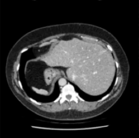

One $\lambda$ **per type of content**: one $\lambda_k$ per organ.

## Conformal regression by organ

A segmentation model $s(X)$ assigns each pixel $j$ to an organ $k$:

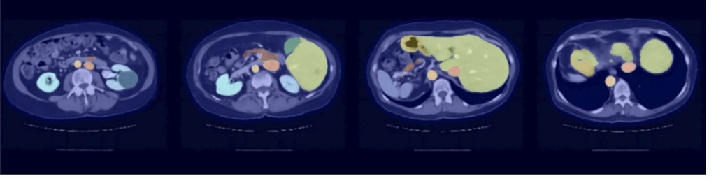

One $\lambda_k$ per organ: $\quad\big[\hat l_j(X)-\lambda_{s(X)_j},\ \hat u_j(X)+\lambda_{s(X)_j}\big]$

$L_k(\lambda)$ = fraction of pixels **of organ $k$** outside the band. Calibrate each $\hat\lambda_k$ as before:
$$\E\big[L_k(\hat\lambda)\big]\le\epsilon \quad\text{for each organ } k$$

[Teneggi, Stayman & S., MICCAI 2025]

## Conformal regression by organ

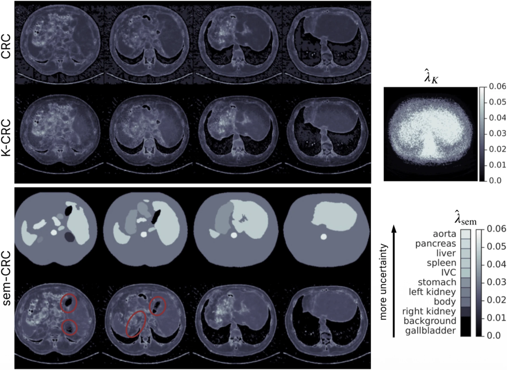

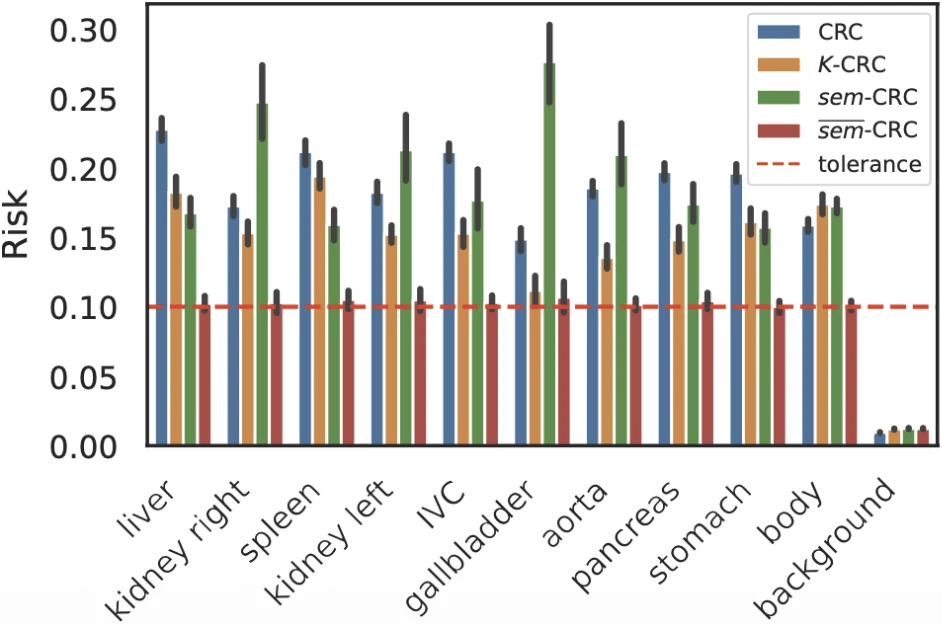

Per-pixel width: more uncertainty in the aorta, pancreas, liver.

Risk by organ: only one $\hat\lambda_k$ per organ (red) gives $\le\epsilon$ in each.

[Teneggi, Stayman & S., MICCAI 2025]

Q2: How does it generalize, and where is it used?

CQR

classification

conditional coverage

risk control

online

## Online conformal

Hourly bike rentals (Washington DC). At each hour $t$:  
**1.** $X_t$ arrives (hour, day, weather) and we publish $\ C_t=\big[\hat Y_t-\tau_t,\ \hat Y_t+\tau_t\big]$  
**2.** $Y_t$ is observed: we cover if $\ S_t=|Y_t-\hat Y_t|\le\tau_t$ $\qquad$ **3.** we update $\tau_{t+1}$

[figure not shown]

**Goal,** for **any** sequence: $\ \ \frac1T\sum_{t\le T}\mathbf 1\{S_t\le\tau_t\}\ \longrightarrow\ 1-\alpha$

No assumptions on the data (exchangeability, independence, distribution).

## Online and by groups

Hourly bike rentals (Washington DC). At each hour $t$:  
**1.** $X_t$ arrives (hour, day, weather) and we publish $\ C_t=\big[\hat Y_t-\tau_t,\ \hat Y_t+\tau_t\big]$  
**2.** $Y_t$ is observed: we cover if $\ S_t=|Y_t-\hat Y_t|\le\tau_t$ $\qquad$ **3.** we update $\tau_{t+1}$  
Groups $\ c_j(X)\in[0,1]$: rush hour, night, weekend, rain; $\ \ T_j=\sum_{t\le T}c_j(X_t)$

[figure not shown]

**Goal,** for **each** group $j$: $\ \ \frac{1}{T_j}\sum_{t\le T}c_j(X_t)\,\mathbf 1\{S_t\le\tau_t\}\ \longrightarrow\ 1-\alpha$

No assumptions on the data (exchangeability, independence, distribution).

## Online conformal by groups

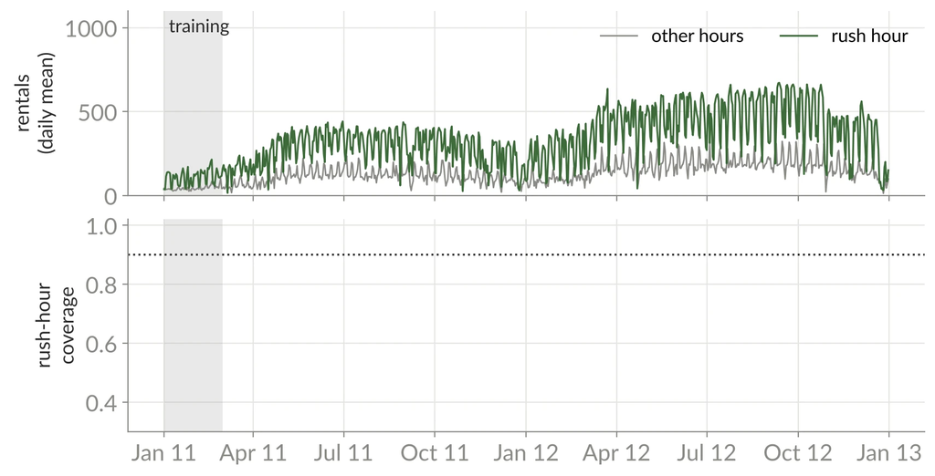

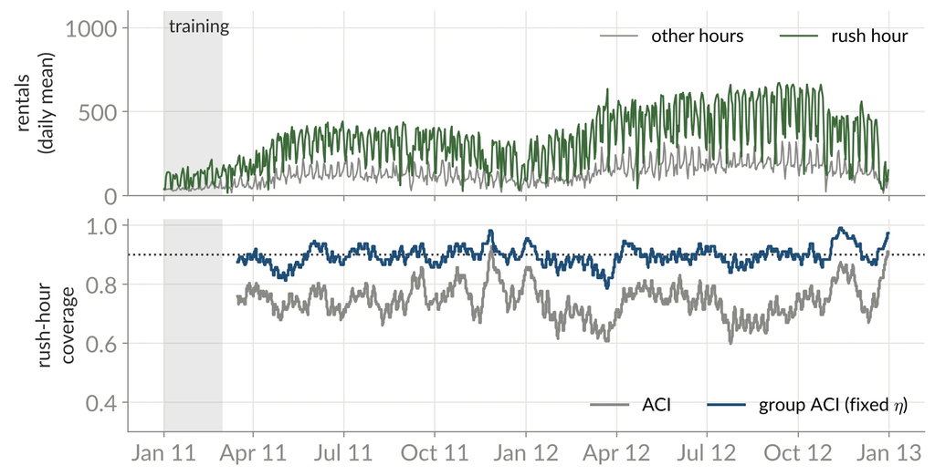

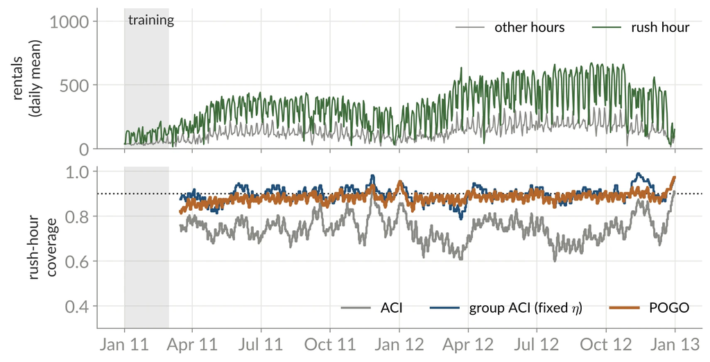

Trained in winter, and usage triples: ~90% per group,  
POGO with no parameters to choose (“parameter-free”).

| method | coverage per group | mean width |
| --- | --- | --- |
| ACI (one radius) | 75–100% | 583 |
| group ACI, $\eta=1$ | 85–96% | 450 |
| group ACI, $\eta=10$ | 90% | 458 |
| group ACI, $\eta=100$ | 90% | 498 |
| **POGO** (no $\eta$) | 88–92% | **445** |

March 2011 – December 2012; 5 groups (all, rush hour, night, weekend, rain). Width in bikes.

[Gibbs & Candès, 2021][Bharti, Pal, Teneggi & S., 2026]

## Summary

- Split conformal: **any** point predictor -> intervals with coverage $\ge 1-\alpha$, using $n$ calibration data points.
- The guarantee follows from **exchangeability + ranks**; it is marginal.
- The **score** depends on the problem: CQR, APS, per group, per pixel, per organ.
- If the data change over time: update online (ACI, POGO).

## References

To get started:

Angelopoulos & Bates, *A Gentle Introduction to Conformal Prediction and Distribution-Free UQ*, 2023

Angelopoulos, Barber & Bates, *Theoretical Foundations of Conformal Prediction*, 2024

Vovk, Gammerman & Shafer, *Algorithmic Learning in a Random World*, 2005

Thanks:  
Jacopo Teneggi · Beepul Bharti · Ambar Pal

Funding: NSF CAREER CCF-2239787 · NIH R01CA287422

jsulam.github.io · jsulam1@jhu.edu